# *EZ_hit-finder* Tutorial

Created on April 24th, 2019.

Authors: Chufeng Li, Nadia Zatsepin

Contact: chufengl@asu.edu; chufengl@icloud.com

Generated from the ASU Research Computing Agave facility.

## Installation and Environment

Setting up the environment:

```
1. install [Anaconda3](https://www.anaconda.com/distribution)
2. conda env create -f ALBA_SX.yml
3. conda activate EZ_hit-finder (source activate EZ_hit-finder)
```

```python
!/bioxfel/local/anaconda3/bin/conda env list
```

```
# conda environments:
#
base                     /bioxfel/local/anaconda3
EZ_hit-finder         *  /bioxfel/local/anaconda3/envs/EZ_hit-finder
                         /home/chufengl/xxli/software/anaconda3
                         /home/chufengl/xxli/software/anaconda3/envs/py27
```

In the terminal environment, instead of this ipython Jupyter notebook enviroment, the "!" is not needed.

In addition, you can directly type "conda" instead of the absolute path name, if that's already set as your default conda and python.Using

```
export PATH=/bioxfel/local/anaconda3/bin:$PATH
```

```python
!source /bioxfel/local/anaconda3/bin/activate EZ_hit-finder
```

Check that this is working in the correct environment, as below:

```python
!/bioxfel/local/anaconda3/bin/conda env list
```

```
# conda environments:
#
base                     /bioxfel/local/anaconda3
EZ_hit-finder         *  /bioxfel/local/anaconda3/envs/EZ_hit-finder
                         /home/chufengl/xxli/software/anaconda3
                         /home/chufengl/xxli/software/anaconda3/envs/py27
```

```python
!pwd
```

```
/data/bioxfel/data/2018/ALBA-2018-Sep-MartinGarcia/analysis/chufengl/scripts
```

## Import all modules needed for the hit-finding processes.

```python
import sys,os
import numpy as np
import fabio
import matplotlib.pyplot as plt
import ALBA_SX_uitils_mpi as AL
```

## Read in a sample .cbf image file for hit-finding parameter tweaking

```python
cbf_file_name='/data/bioxfel/data/2018/ALBA-2018-Sep-MartinGarcia/data/Lyso2000/images/Lyso2000_17_6484.cbf'
img_array_s=fabio.open(cbf_file_name)
print('The image dimension is:',img_array_s.data.shape)
center_x=np.round(img_array_s.data.shape[0]/2).astype(np.int16)
center_y=np.round(img_array_s.data.shape[1]/2).astype(np.int16)
print('The beam center is preliminarily: (%.2f,%.2f)'%(center_x,center_y))
```

```
The image dimension is: (2527, 2463)
The beam center is preliminarily: (1264.00,1232.00)
```

**Parameter_tweaking mode:**

```
label_filtered_sorted,weighted_centroid_filtered,props= \
single_peak_finder(CBF_file_name,thld,min_pix,max_pix,mask_file,interact='True')
```

- thld: pixel value threshold
- min_pix: minimal number of pixels for a peak
- max_pix: maximal number of pixels for a peak
- mask_file: name of the mask file
- min_peak: minimal number of peaks for a hit

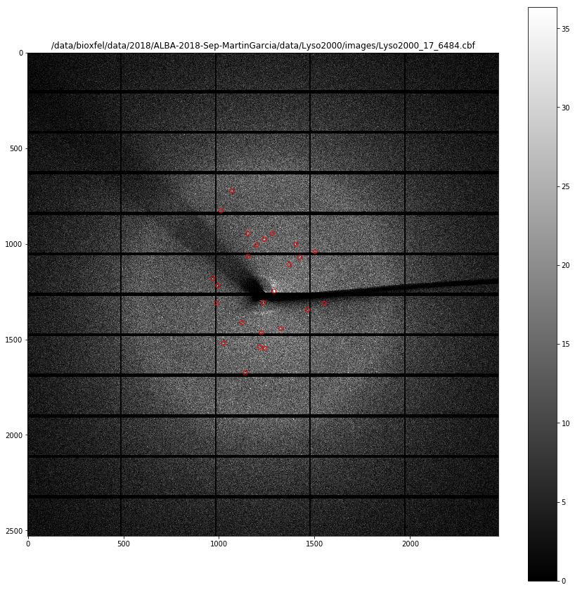

```python
label_filtered_sorted,weighted_centroid_filtered,props=AL.single_peak_finder(cbf_file_name,50,3,20,'None',interact='True')
```

## Run hit-finding with tuned parameters

After satisfied with the parmameter tuning above in the interactive mode, we can run the hit fiding in batch mode using the optimized parameters as follows:

Usage:

```
ALBA_SX_uitils.py <cbf_file_list_file> <thld> <min_pix> <max_pix> <mask_file> <min_peak> <Region>
```

- thld: pixel value threshold
- min_pix: minimal number of pixels for a peak
- max_pix: maximal number of pixels for a peak
- mask_file: name of the mask file
- min_peak: minimal number of peaks for a hit
- Region: 'ALL'(full image), 'C'(central portion), 'Q'(quarter)

```python
!python ../../chufengl/scripts/ALBA_SX_uitils_mpi.py ../test_split.lst00000 50 3 20 None 10 C
```

```
Started on 4-20-2019
Authors: Chufeng Li, Nadia Zatsepin
E-mail: chufengl@asu.edu
Usage:
    ALBA_SX_uitils.py <cbf_file_list_file> <thld> <min_pix> <max_pix> <mask_file> <min_peak> <Region>
    thld: pixel value threshold
    min_pix: minimal number of pixels for a peak
    max_pix: maximal number of pixels for a peak
    mask_file: name of the mask file
    min_peak: minimal number of peaks for a hit
    Region: 'ALL', 'C', 'Q'

Parameter_tweaking mode:

label_filtered_sorted,weighted_centroid_filtered,props= single_peak_finder(CBF_file_name,thld,min_pix,max_pix,mask_file,interact='True')


HIT!!!!  Event 0: 25 peaks found
BLANK!   Event 1: 4 peaks found
BLANK!   Event 2: 3 peaks found
BLANK!   Event 3: 4 peaks found
BLANK!   Event 4: 1 peaks found
BLANK!   Event 5: 1 peaks found
HIT!!!!  Event 6: 62 peaks found
BLANK!   Event 7: 1 peaks found
HIT!!!!  Event 8: 18 peaks found
HIT!!!!  Event 9: 10 peaks found
BLANK!   Event 10: 1 peaks found
BLANK!   Event 11: 1 peaks found
BLANK!   Event 12: 4 peaks found
HIT!!!!  Event 13: 40 peaks found
BLANK!   Event 14: 1 peaks found
BLANK!   Event 15: 1 peaks found
BLANK!   Event 16: 5 peaks found
BLANK!   Event 17: 1 peaks found
BLANK!   Event 18: 7 peaks found
BLANK!   Event 19: 1 peaks found
BLANK!   Event 20: 4 peaks found
BLANK!   Event 21: 1 peaks found
BLANK!   Event 22: 2 peaks found
```

[output cut: 470 more lines]

```
BLANK!   Event 493: 3 peaks found
BLANK!   Event 494: 1 peaks found
BLANK!   Event 495: 6 peaks found
BLANK!   Event 496: 4 peaks found
BLANK!   Event 497: 5 peaks found
BLANK!   Event 498: 5 peaks found
BLANK!   Event 499: 1 peaks found
/data/bioxfel/data/2018/ALBA-2018-Sep-MartinGarcia/analysis/chufengl/test_split.lst00000
100   out of  500  hits found!
HIT rate: 20.00 %
HIT events:
[0, 6, 8, 9, 13, 24, 25, 31, 36, 41, 42, 44, 49, 55, 63, 64, 77, 78, 79, 85, 92, 93, 95, 96, 105, 109, 110, 113, 114, 128, 135, 137, 142, 145, 156, 159, 162, 165, 168, 170, 184, 185, 192, 208, 211, 213, 219, 233, 237, 238, 239, 240, 241, 246, 251, 259, 267, 304, 305, 306, 309, 311, 320, 324, 333, 33…
Peak information saved in test_split.lst00000_peak_info.pkl
/data/bioxfel/data/2018/ALBA-2018-Sep-MartinGarcia/analysis/chufengl/test_split.lst00000
 took  42.956661 seconds.
```

```python
!ls -lrth
```

```
total 13M
drwxrwsr-x 2 chufengl bioxfel 595K Apr 21 05:19 lists
-rw-rw-r-- 1 chufengl bioxfel 8.0K Apr 21 06:14 ALBA_SX.yml
-rw-r--r-- 1 chufengl bioxfel 9.5K Apr 22 01:37 ALBA_SX_uitils_mpi.py
drwxrwsr-x 2 chufengl bioxfel  512 Apr 24 17:12 __pycache__
-rw-rw-r-- 1 chufengl bioxfel  12M Apr 25 00:00 test_split.lst00000_peak_info.pkl
-rw-rw-r-- 1 chufengl bioxfel  18K Apr 25 00:00 test_split.lst00000HIT.log
-rw-rw-r-- 1 chufengl bioxfel 9.1K Apr 25 00:00 test_split.lst00000eve.lst
-rw-rw-r-- 1 chufengl bioxfel 851K Apr 25 00:01 EZ_hit-finder_tutorial.ipynb
```

## Check the output files

.log, eve.lst , and .pkl files are generated for each hit-fingding batch.

- .log: log file of the hit-finding
- eve.lst: hit event list, used for data transfer
- .pkl: binary file consisting of the peak information, adopting Cheetah and CrystFEL convention.

```python
!cat test_split.lst00000HIT.log
```

[output not shown]

[output cut: 459 more lines]

```
HIT!!!!  Event 490: 44 peaks found
BLANK!   Event 491: 2 peaks found
HIT!!!!  Event 492: 23 peaks found
BLANK!   Event 493: 3 peaks found
BLANK!   Event 494: 1 peaks found
BLANK!   Event 495: 6 peaks found
BLANK!   Event 496: 4 peaks found
BLANK!   Event 497: 5 peaks found
BLANK!   Event 498: 5 peaks found
BLANK!   Event 499: 1 peaks found
------------------------------------------------------------------
/data/bioxfel/data/2018/ALBA-2018-Sep-MartinGarcia/analysis/chufengl/test_split.lst00000
 100   out of  500  hits found!
 HIT rate: 20.00 %
------------------------------------------------------------------
```

```python
!cat test_split.lst00000eve.lst
```

```
/data/bioxfel/data/2018/ALBA-2018-Sep-MartinGarcia/data/Lyso2000/images/Lyso2000_17_6484.cbf
/data/bioxfel/data/2018/ALBA-2018-Sep-MartinGarcia/data/Lyso2000/images/Lyso2000_41_6172.cbf
/data/bioxfel/data/2018/ALBA-2018-Sep-MartinGarcia/data/Lyso2000/images/Lyso2000_44_7339.cbf
/data/bioxfel/data/2018/ALBA-2018-Sep-MartinGarcia/data/Lyso2000/images/Lyso2000_1_2989.cbf
/data/bioxfel/data/2018/ALBA-2018-Sep-MartinGarcia/data/Lyso2000/images/Lyso2000_11_1523.cbf
/data/bioxfel/data/2018/ALBA-2018-Sep-MartinGarcia/data/Lyso2000/images/Lyso2000_59_6964.cbf
/data/bioxfel/data/2018/ALBA-2018-Sep-MartinGarcia/data/Lyso2000/images/Lyso2000_47_2497.cbf
/data/bioxfel/data/2018/ALBA-2018-Sep-MartinGarcia/data/Lyso2000/images/Lyso2000_47_6172.cbf
/data/bioxfel/data/2018/ALBA-2018-Sep-MartinGarcia/data/Lyso2000/images/Lyso2000_3_8850.cbf
/data/bioxfel/data/2018/ALBA-2018-Sep-MartinGarcia/data/Lyso2000/images/Lyso2000_44_9864.cbf
/data/bioxfel/data/2018/ALBA-2018-Sep-MartinGarcia/data/Lyso2000/images/Lyso2000_47_8064.cbf
/data/bioxfel/data/2018/ALBA-2018-Sep-MartinGarcia/data/Lyso2000/images/Lyso2000_45_9660.cbf
/data/bioxfel/data/2018/ALBA-2018-Sep-MartinGarcia/data/Lyso2000/images/Lyso2000_4_3704.cbf
/data/bioxfel/data/2018/ALBA-2018-Sep-MartinGarcia/data/Lyso2000/images/Lyso2000_42_3729.cbf
/data/bioxfel/data/2018/ALBA-2018-Sep-MartinGarcia/data/Lyso2000/images/Lyso2000_40_5741.cbf
/data/bioxfel/data/2018/ALBA-2018-Sep-MartinGarcia/data/Lyso2000/images/Lyso2000_39_7097.cbf
/data/bioxfel/data/2018/ALBA-2018-Sep-MartinGarcia/data/Lyso2000/images/Lyso2000_46_6661.cbf
/data/bioxfel/data/2018/ALBA-2018-Sep-MartinGarcia/data/Lyso2000/images/Lyso2000_40_7882.cbf
/data/bioxfel/data/2018/ALBA-2018-Sep-MartinGarcia/data/Lyso2000/images/Lyso2000_43_6082.cbf
/data/bioxfel/data/2018/ALBA-2018-Sep-MartinGarcia/data/Lyso2000/images/Lyso2000_59_4532.cbf
/data/bioxfel/data/2018/ALBA-2018-Sep-MartinGarcia/data/Lyso2000/images/Lyso2000_18_7299.cbf
/data/bioxfel/data/2018/ALBA-2018-Sep-MartinGarcia/data/Lyso2000/images/Lyso2000_40_9424.cbf
/data/bioxfel/data/2018/ALBA-2018-Sep-MartinGarcia/data/Lyso2000/images/Lyso2000_41_1256.cbf
/data/bioxfel/data/2018/ALBA-2018-Sep-MartinGarcia/data/Lyso2000/images/Lyso2000_46_0661.cbf
/data/bioxfel/data/2018/ALBA-2018-Sep-MartinGarcia/data/Lyso2000/images/Lyso2000_47_3744.cbf
/data/bioxfel/data/2018/ALBA-2018-Sep-MartinGarcia/data/Lyso2000/images/Lyso2000_45_1833.cbf
/data/bioxfel/data/2018/ALBA-2018-Sep-MartinGarcia/data/Lyso2000/images/Lyso2000_46_0764.cbf
/data/bioxfel/data/2018/ALBA-2018-Sep-MartinGarcia/data/Lyso2000/images/Lyso2000_40_0110.cbf
/data/bioxfel/data/2018/ALBA-2018-Sep-MartinGarcia/data/Lyso2000/images/Lyso2000_41_1910.cbf
/data/bioxfel/data/2018/ALBA-2018-Sep-MartinGarcia/data/Lyso2000/images/Lyso2000_59_3288.cbf
/data/bioxfel/data/2018/ALBA-2018-Sep-MartinGarcia/data/Lyso2000/images/Lyso2000_42_1334.cbf
/data/bioxfel/data/2018/ALBA-2018-Sep-MartinGarcia/data/Lyso2000/images/Lyso2000_18_3772.cbf
/data/bioxfel/data/2018/ALBA-2018-Sep-MartinGarcia/data/Lyso2000/images/Lyso2000_60_1713.cbf
/data/bioxfel/data/2018/ALBA-2018-Sep-MartinGarcia/data/Lyso2000/images/Lyso2000_43_3462.cbf
/data/bioxfel/data/2018/ALBA-2018-Sep-MartinGarcia/data/Lyso2000/images/Lyso2000_44_8319.cbf
/data/bioxfel/data/2018/ALBA-2018-Sep-MartinGarcia/data/Lyso2000/images/Lyso2000_59_1303.cbf
/data/bioxfel/data/2018/ALBA-2018-Sep-MartinGarcia/data/Lyso2000/images/Lyso2000_44_8328.cbf
/data/bioxfel/data/2018/ALBA-2018-Sep-MartinGarcia/data/Lyso2000/images/Lyso2000_47_5714.cbf
/data/bioxfel/data/2018/ALBA-2018-Sep-MartinGarcia/data/Lyso2000/images/Lyso2000_45_0676.cbf
/data/bioxfel/data/2018/ALBA-2018-Sep-MartinGarcia/data/Lyso2000/images/Lyso2000_39_6980.cbf
```

[output cut: 45 more lines]

```
/data/bioxfel/data/2018/ALBA-2018-Sep-MartinGarcia/data/Lyso2000/images/Lyso2000_11_8390.cbf
/data/bioxfel/data/2018/ALBA-2018-Sep-MartinGarcia/data/Lyso2000/images/Lyso2000_47_8522.cbf
/data/bioxfel/data/2018/ALBA-2018-Sep-MartinGarcia/data/Lyso2000/images/Lyso2000_39_0710.cbf
/data/bioxfel/data/2018/ALBA-2018-Sep-MartinGarcia/data/Lyso2000/images/Lyso2000_40_7703.cbf
/data/bioxfel/data/2018/ALBA-2018-Sep-MartinGarcia/data/Lyso2000/images/Lyso2000_43_6256.cbf
/data/bioxfel/data/2018/ALBA-2018-Sep-MartinGarcia/data/Lyso2000/images/Lyso2000_44_3540.cbf
/data/bioxfel/data/2018/ALBA-2018-Sep-MartinGarcia/data/Lyso2000/images/Lyso2000_12_1704.cbf
/data/bioxfel/data/2018/ALBA-2018-Sep-MartinGarcia/data/Lyso2000/images/Lyso2000_43_7631.cbf
/data/bioxfel/data/2018/ALBA-2018-Sep-MartinGarcia/data/Lyso2000/images/Lyso2000_42_3646.cbf
/data/bioxfel/data/2018/ALBA-2018-Sep-MartinGarcia/data/Lyso2000/images/Lyso2000_10_9271.cbf
/data/bioxfel/data/2018/ALBA-2018-Sep-MartinGarcia/data/Lyso2000/images/Lyso2000_18_4655.cbf
/data/bioxfel/data/2018/ALBA-2018-Sep-MartinGarcia/data/Lyso2000/images/Lyso2000_44_6683.cbf
/data/bioxfel/data/2018/ALBA-2018-Sep-MartinGarcia/data/Lyso2000/images/Lyso2000_46_2593.cbf
/data/bioxfel/data/2018/ALBA-2018-Sep-MartinGarcia/data/Lyso2000/images/Lyso2000_18_7457.cbf
/data/bioxfel/data/2018/ALBA-2018-Sep-MartinGarcia/data/Lyso2000/images/Lyso2000_1_2376.cbf
```

## Check the distribution of peaks as a first diagnosis using .pkl file

```python
import pickle as pk
f=open('test_split.lst00000_peak_info.pkl','rb')
peak_dict=pk.load(f)
f.close()
peak_dict.keys()
```

```
dict_keys(['cbf_file_list_file', 'nPeaks', 'peakTotalIntensity', 'peakXPosRaw', 'peakYPosRaw'])
```

```
There are 10328 peaks for the files in the list "/data/bioxfel/data/2018/ALBA-2018-Sep-MartinGarcia/analysis/chufengl/test_split.lst00000"
```

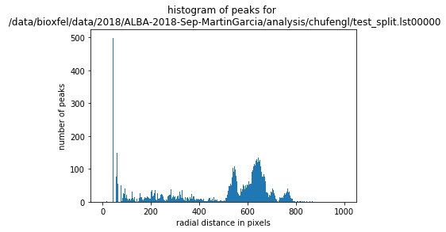

```python
cbf_file_list_file=peak_dict['cbf_file_list_file']
nPeaks=peak_dict['nPeaks']
peakXPosRaw=peak_dict['peakXPosRaw']
peakYPosRaw=peak_dict['peakYPosRaw']
#print(peakXPosRaw.shape)
#print(nPeaks.shape)
Npeaks=nPeaks.sum()
print('There are %d peaks for the files in the list "%s"'%(Npeaks,cbf_file_list_file))
peakX=peakXPosRaw.reshape(-1,)
#print(peakX.shape)
peakX=peakX[peakX!=0]
#print(peakX.shape)
peakY=peakYPosRaw.reshape(-1,)
#print(peakY.shape)
peakY=peakY[peakY!=0]
#print(peakY.shape)
RD=np.sqrt((peakX-center_x)**2+(peakY-center_y)**2);
#print(RD.shape)
plt.figure()
plt.hist(RD,bins=np.linspace(0,1000,500));
plt.xlabel('radial distance in pixels')
plt.ylabel('number of peaks')
plt.title('histogram of peaks for \n %s'%(cbf_file_list_file));
```

## Tips:

1. split the .cbf file list into batches of smaller ones using "split -d ", so that multiples processes of hit-finding can be launched simultaneously.
2. Copy only the "hits" to your hard drive, by using "rsync --files-from=*.eve.lst "
3. Check the configuration of the computation system always, before launching multiples processes.